```
FALSE     Edu2.FM          Labo.FM          Edu.Exp         Life.Exp
FALSE  Min.   :0.1717   Min.   :0.1857   Min.   : 7.00   Min.   :49.00
FALSE  1st Qu.:0.7427   1st Qu.:0.6005   1st Qu.:11.30   1st Qu.:66.42
FALSE  Median :0.9402   Median :0.7576   Median :13.50   Median :74.20
FALSE  Mean   :0.8564   Mean   :0.7091   Mean   :13.23   Mean   :71.72
FALSE  3rd Qu.:0.9968   3rd Qu.:0.8538   3rd Qu.:15.20   3rd Qu.:77.28
FALSE  Max.   :1.4967   Max.   :1.0380   Max.   :20.20   Max.   :83.50
FALSE       GNI            Mat.Mor          Ado.Birth         Parli.F
FALSE  Min.   :  2.00   Min.   :   1.00   Min.   :  0.60   Min.   : 0.00
FALSE  1st Qu.: 53.25   1st Qu.:  11.25   1st Qu.: 12.62   1st Qu.:12.40
FALSE  Median : 98.50   Median :  49.00   Median : 33.20   Median :19.35
FALSE  Mean   : 98.11   Mean   : 145.96   Mean   : 46.14   Mean   :20.96
FALSE  3rd Qu.:142.75   3rd Qu.: 190.00   3rd Qu.: 71.78   3rd Qu.:28.07
FALSE  Max.   :192.00   Max.   :1100.00   Max.   :175.60   Max.   :57.50
```

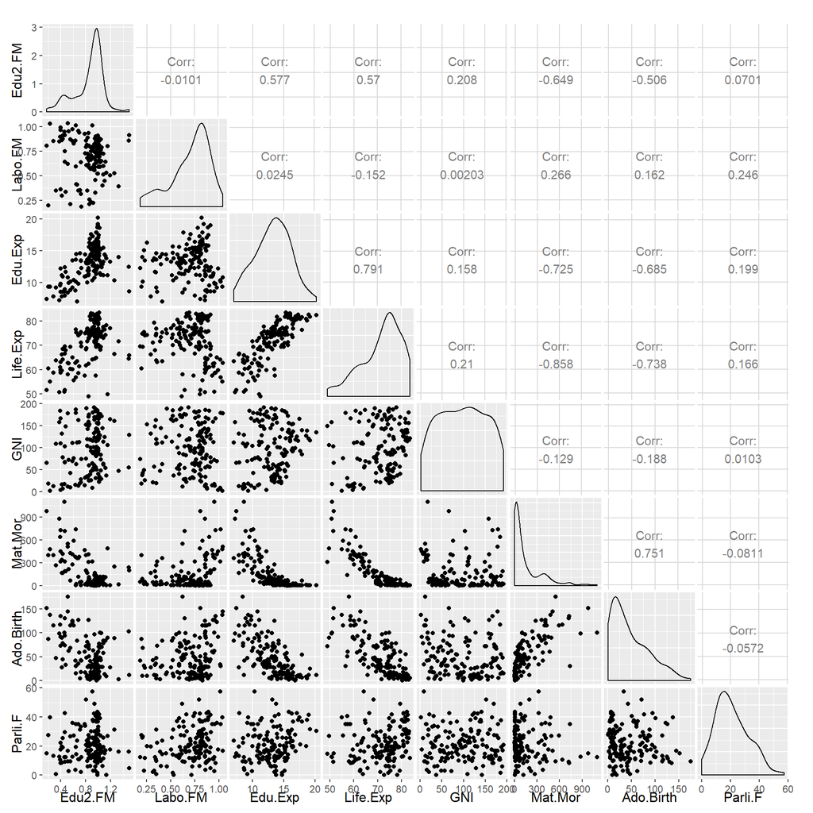

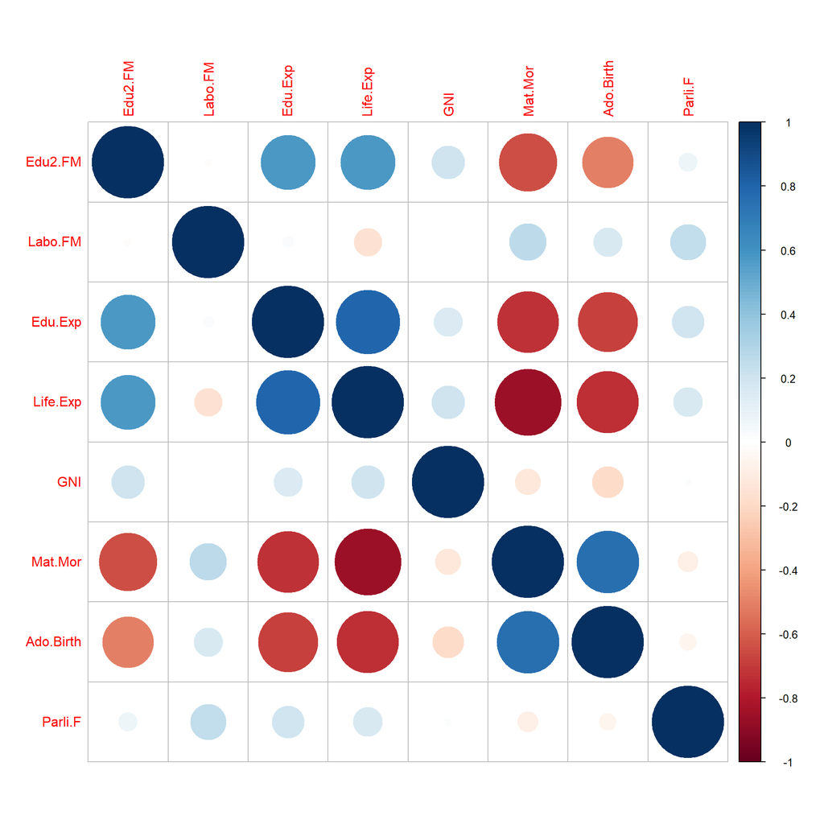

From the correlation matrix we can see that maternal mortality is strongly correlated with adolescent birthrate. They are both anticorrelated with education and life expectancy (which correlate with each other). Femala/male ratio in education correlates with education and life expectancy, and anticorrelates with maternal mortality and adoslectent birth rate.

## Principal component analysis

We will now use a method called principal component analysis for reducing the number of variables in the data. PCA will reduce the dimensionality of the data by creating principal components that explain the different dimensions of variability in the data. PCA1 explains most of the variability, PCA2 the second most and so on. Let’s use bipolots for visualizing the components, we are doing this first without scaling the data and then with the scaled data:

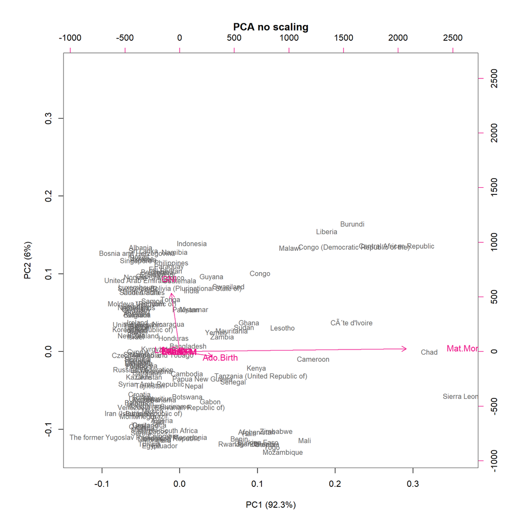

From the plot above we can see that in the non-standardized data, maternal mortality seems to explain most of the variability in the data. It is strongly correlated with PC1 which explains 92% of the variance in the data. PCA2 only explains 6% of the variance and is mostly correlated wiht GNI. We can predict that these results are highly affected by the difference in the variance of the non-standardized variables. Maternal mortality ranges from 1 to 1100, so it has clearly higher variance than the other variables, and hence it of course explains most of the variance in the data.

Let’s now standardize the data and do the PCA again.

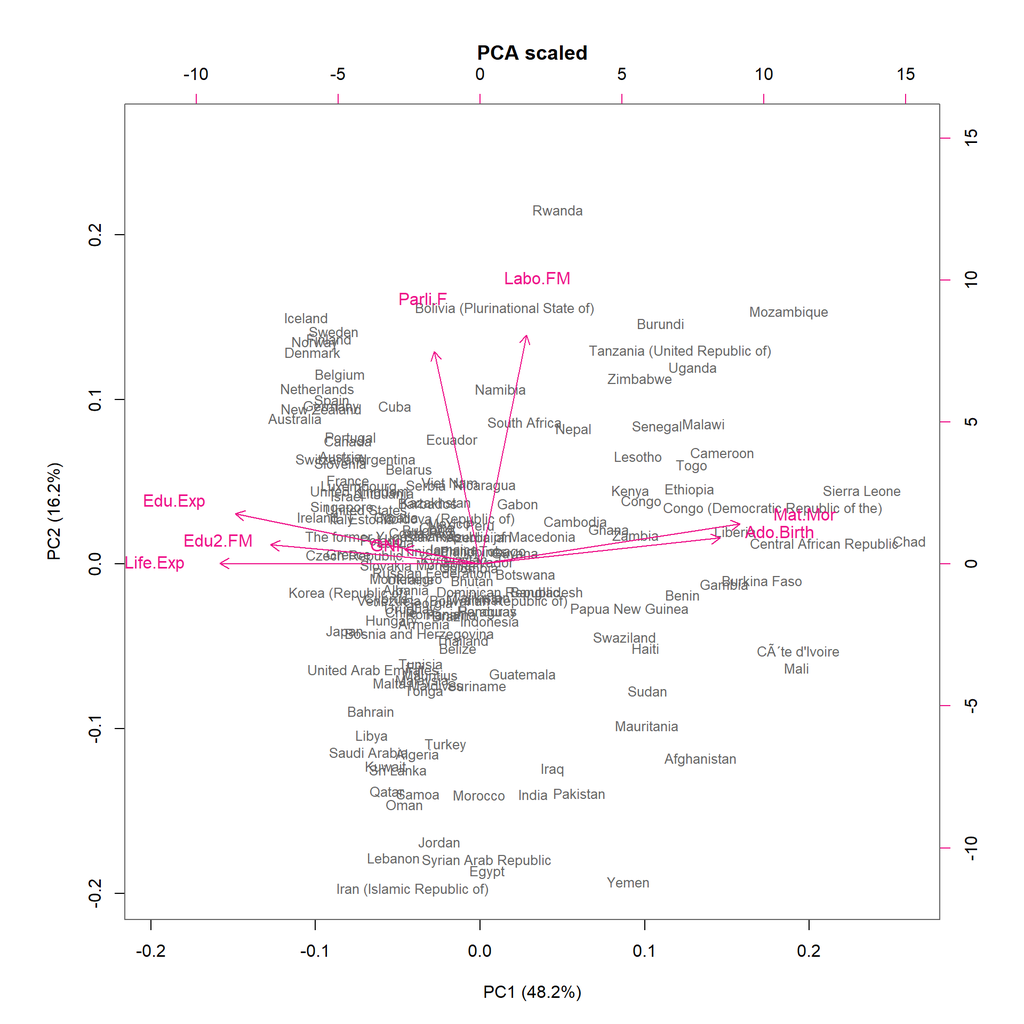

After standardization we can see that the variance in the data is actually explained by other factors as well. PC1 explains almost half of the variance in the data, and it is formed by life expectancy, education ratio between the genders, and education expectancy, maternal mortality, and birthrate. Hence we can say that education in general explains most of the variance in the data. Education is likely to also decrease the maternal mortality and birthrate.

PC2 explains 16% of the variance, and it is formed by female participation in the parliament and gender ratio in the labour. This component mainly reflects the equality of women and men in the society, and the chances of women to participate in decision making.

## MCA with categorical variables (Tea dataset)

Let’s now explore a categorical data set. We are using ‘tea’ data set as an example. Tea is included in the FactoMineR package and more information about it can be found [here](https://rdrr.io/cran/FactoMineR/man/tea.html).

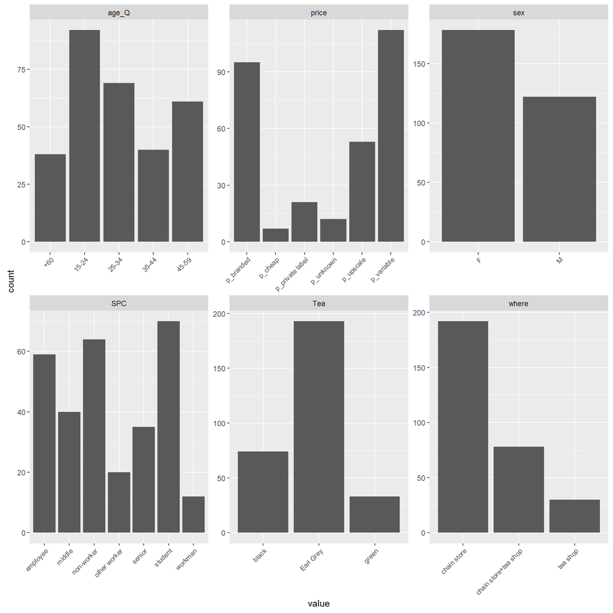

We now have a dataset with 6 categorical variables that describe the different aspects of tea consumption. There are 300 observations. Let’s now do MCA for the dataset. MCA corresponds PCA but it can be used factorized variables.

```
##
## Call:
## MCA(X = tea_time, graph = FALSE)
##
##
## Eigenvalues
##                        Dim.1   Dim.2   Dim.3   Dim.4   Dim.5   Dim.6
## Variance               0.373   0.299   0.244   0.229   0.205   0.194
## % of var.             11.194   8.973   7.320   6.874   6.164   5.809
## Cumulative % of var.  11.194  20.167  27.487  34.360  40.524  46.334
##                        Dim.7   Dim.8   Dim.9  Dim.10  Dim.11  Dim.12
## Variance               0.192   0.177   0.174   0.172   0.166   0.156
## % of var.              5.758   5.320   5.230   5.173   4.966   4.683
## Cumulative % of var.  52.092  57.412  62.642  67.815  72.781  77.464
##                       Dim.13  Dim.14  Dim.15  Dim.16  Dim.17  Dim.18
## Variance               0.141   0.121   0.119   0.112   0.095   0.065
## % of var.              4.235   3.621   3.565   3.367   2.848   1.964
## Cumulative % of var.  81.699  85.320  88.885  92.252  95.100  97.064
##                       Dim.19  Dim.20
## Variance               0.052   0.045
## % of var.              1.573   1.363
## Cumulative % of var.  98.637 100.000
##
## Individuals (the 10 first)
##                 Dim.1    ctr   cos2    Dim.2    ctr   cos2    Dim.3    ctr
## 1            |  0.416  0.154  0.025 |  0.852  0.809  0.103 | -0.221  0.067
## 2            |  0.238  0.051  0.021 |  0.157  0.027  0.009 | -0.089  0.011
## 3            | -0.099  0.009  0.003 |  0.296  0.098  0.025 | -0.122  0.020
## 4            | -0.744  0.495  0.339 |  0.031  0.001  0.001 | -0.325  0.144
## 5            | -0.119  0.013  0.007 |  0.394  0.173  0.076 |  0.184  0.046
## 6            | -0.907  0.735  0.231 |  0.087  0.008  0.002 |  0.161  0.035
## 7            |  0.243  0.053  0.019 |  0.631  0.444  0.130 | -0.621  0.528
## 8            |  0.299  0.080  0.028 |  0.210  0.049  0.014 | -0.476  0.310
## 9            |  0.806  0.580  0.165 |  0.518  0.299  0.068 | -0.915  1.144
## 10           |  1.080  1.042  0.268 |  0.414  0.191  0.039 | -0.793  0.859
##                cos2
## 1             0.007 |
## 2             0.003 |
## 3             0.004 |
## 4             0.065 |
```

[output cut: 24 more lines]

```
## M              6.896 |   0.151   0.637   0.016   2.168 |
## employee       2.777 |   0.625   5.244   0.096   5.345 |
## middle         4.740 |  -0.291   0.771   0.013  -1.974 |
## non-worker   -13.001 |   0.279   1.137   0.021   2.515 |
## other worker   3.771 |  -0.025   0.003   0.000  -0.117 |
## senior         5.837 |  -0.614   3.004   0.050  -3.858 |
##
## Categorical variables (eta2)
##                Dim.1 Dim.2 Dim.3
## Tea          | 0.231 0.022 0.266 |
## sex          | 0.092 0.159 0.016 |
## SPC          | 0.578 0.722 0.172 |
## price        | 0.347 0.095 0.424 |
## age_Q        | 0.630 0.713 0.141 |
## where        | 0.362 0.084 0.446 |
```

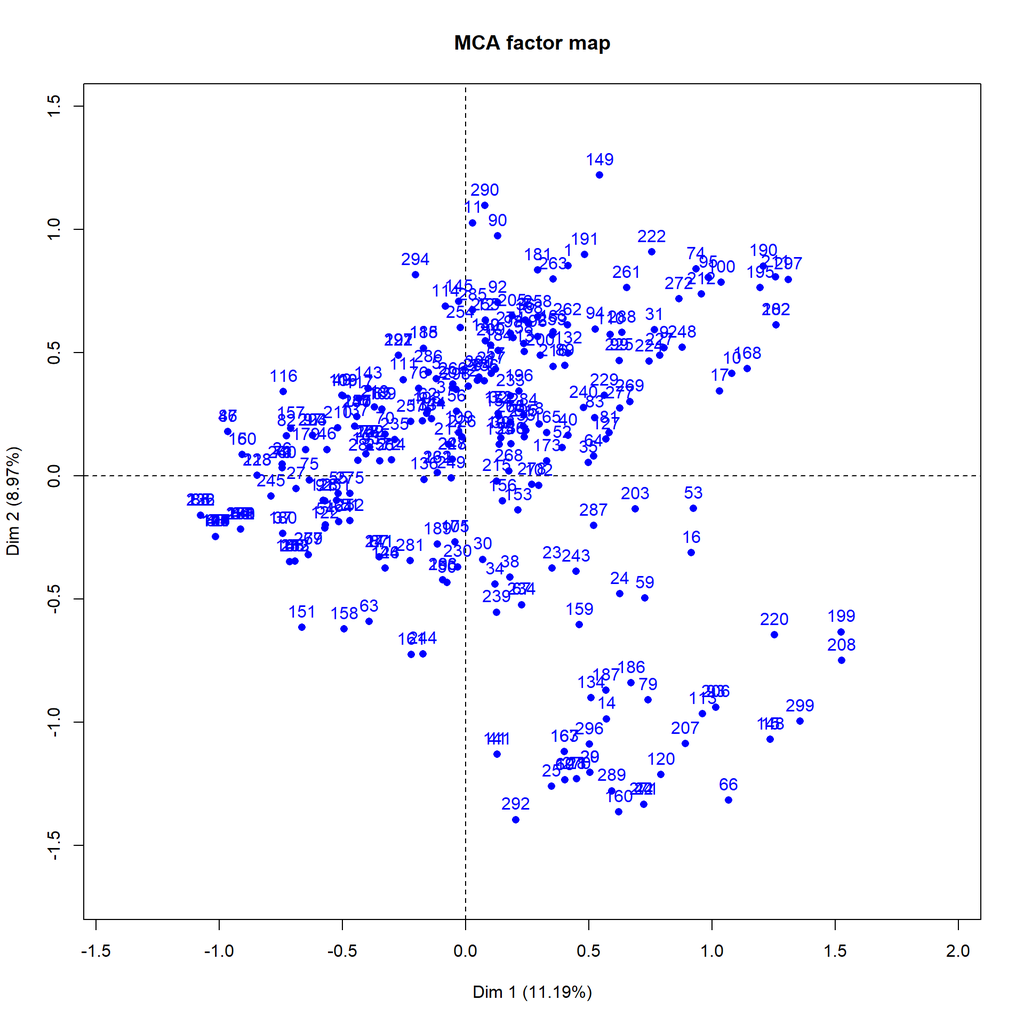

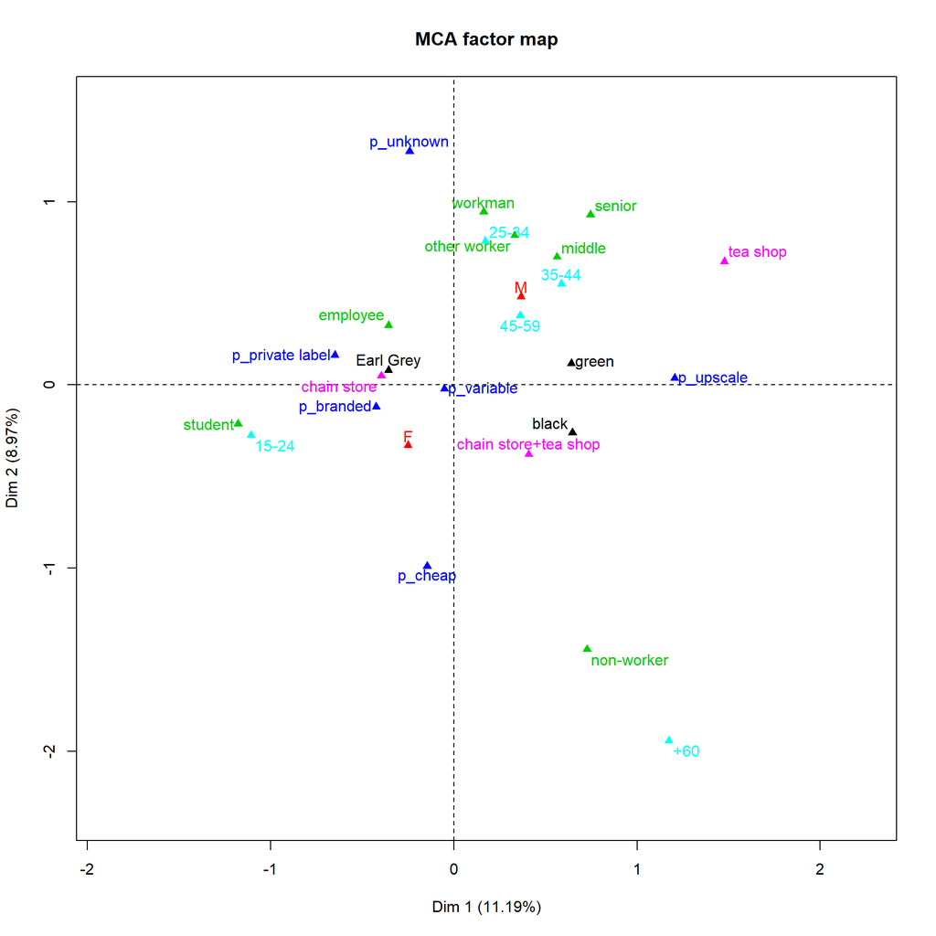

None of the selected varibles seem to explain the variance very clearly, the MCA plot with the variables is quite scattered, no conclusions can be drawn from this data. The +60 age class and non-workers seem to stand out from the rest of the group, but we should probably choose some other variables to explain how they differ from the other consumers.